# **ANALIZA PORÓWNAWCZA MORFOLOGII TRZECH GATUNKÓW IRYSÓW**

## WSTĘP DO ANALIZY

Zbiór danych, który został poddany analizie, zawiera 150 próbek kwiatów, po 50 próbek dla każdego z trzech gatunków irysów: Iris setosa, Iris versicolor oraz Iris virginica. Celem analizy jest porównanie morfologii tych gatunków pod kątem czterech cech pomiarowych: długości i szerokości działki kielicha oraz długości i szerokości płatka.

Każdy wiersz w zbiorze danych przedstawia pojedynczy kwiat, a wartości pomiarów są wyrażone w centymetrach. Dane te stanowią cenną podstawę do przeprowadzenia porównań międzygatunkowych, pozwalając na ocenę różnic w budowie kwiatów oraz identyfikację cech, które najbardziej różnicują poszczególne gatunki.

W ramach tej analizy, szczególną uwagę zwrócono na zmienność wielkości poszczególnych cech w obrębie każdego gatunku oraz na to, które z tych cech mogą stanowić istotne kryteria w identyfikacji gatunków irysów.

## Zdjęcia kwiatów

[figure not shown]

**Iris-virginica**

[figure not shown]

**Iris-versicolor**

[figure not shown]

**Iris-sentosa**

## **1. OGÓLNE SPOJRZENIE NA DANE**

|  | długość kielicha (sepal length) | szerokość kielicha (sepal width) | długość płatka (petal length) | szerokość płatka (petal width) | klasa (class) |
| --- | --- | --- | --- | --- | --- |
| 129 | 7.2 | 3.0 | 5.8 | 1.6 | Iris-virginica |
| 67 | 5.8 | 2.7 | 4.1 | 1.0 | Iris-versicolor |
| 83 | 6.0 | 2.7 | 5.1 | 1.6 | Iris-versicolor |
| 65 | 6.7 | 3.1 | 4.4 | 1.4 | Iris-versicolor |
| 123 | 6.3 | 2.7 | 4.9 | 1.8 | Iris-virginica |
| 14 | 5.8 | 4.0 | 1.2 | 0.2 | Iris-setosa |
| 62 | 6.0 | 2.2 | 4.0 | 1.0 | Iris-versicolor |
| 79 | 5.7 | 2.6 | 3.5 | 1.0 | Iris-versicolor |
| 13 | 4.3 | 3.0 | 1.1 | 0.1 | Iris-setosa |
| 16 | 5.4 | 3.9 | 1.3 | 0.4 | Iris-setosa |

## **2. ANALIZA ŚREDNICH PARAMETRÓW**

### - Setosa

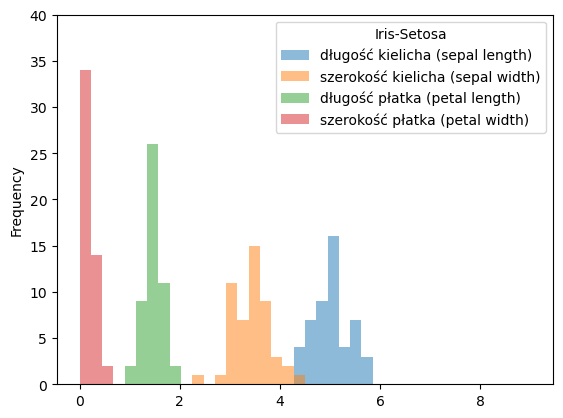

### - Versicolor

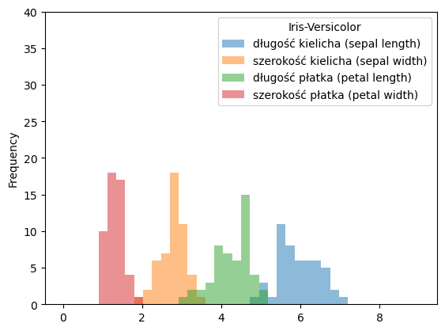

### - Virginica

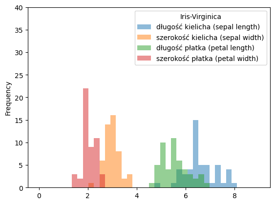

## **WNIOSKI Z ANALIZY PARAMETRÓW:**

### Szerokość płatków (petal width):

##### - Iris setosa ma najwęższe płatki – od 0,1 do 0,6 cm, z dominującą wartością 0,2 cm.

##### - Iris versicolor osiąga szerokości od 1 do 1,8 cm, a najczęściej spotykane są wartości między 1,3 a 1,5 cm.

##### - Iris virginica ma najszersze płatki – od 1,4 do 2,5 cm, z dominującym przedziałem 1,8–2,1 cm.

## **3. ANALIZA KORELACJI DLA POSZCZEGÓLNYCH GATUNKÓW**

### a. Iris - Setosa

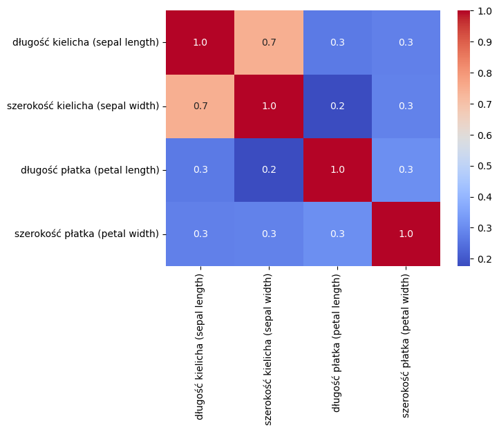

### b. Iris - Versicolor

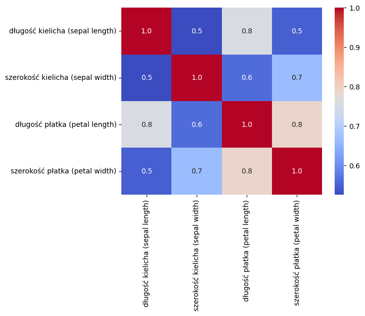

### c. Iris - Virginica

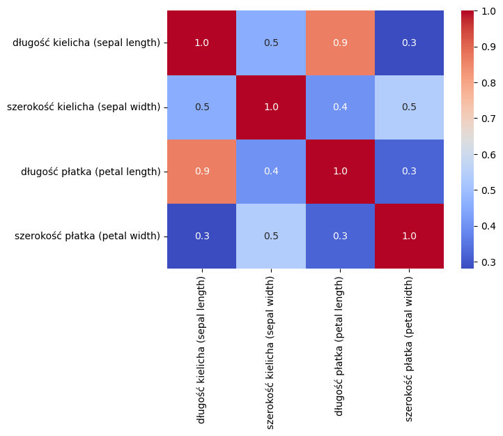

## **WNIOSKI**:

#### * Długość kielicha i szerokość kielicha w Iris setosa: Długość kielicha w Iris setosa wykazuje silniejszą korelację ze szerokością kielicha, w porównaniu do Iris versicolor i Iris virginica.

#### * Długość kielicha a rozmiary płatków w Iris setosa: Długość kielicha w Iris setosa jest mniej skorelowana z rozmiarami płatków w porównaniu do Iris versicolor i Iris virginica.

#### * Długość płatka a szerokość płatka w Iris versicolor: W Iris versicolor długość płatka jest najsilniej skorelowana ze szerokością płatka.

## **4. ANALIZA WARTOŚCI ODSTAJĄCYCH**

#### a. Iris - Setosa

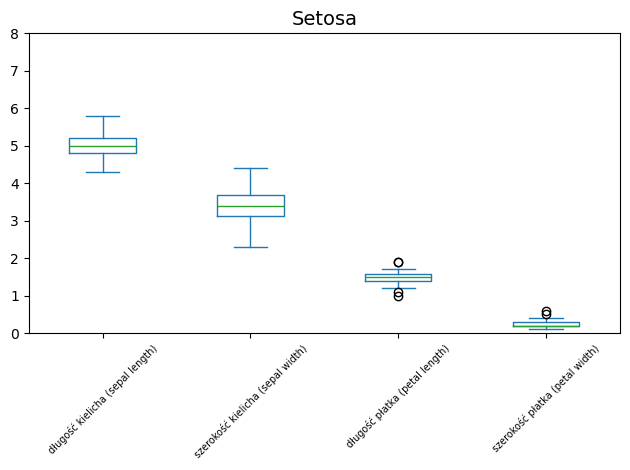

#### b. Iris - Versicolor

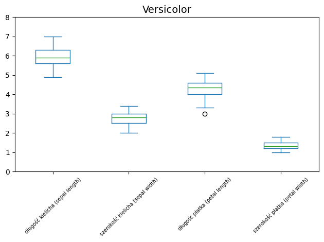

#### c. Iris - Virginica

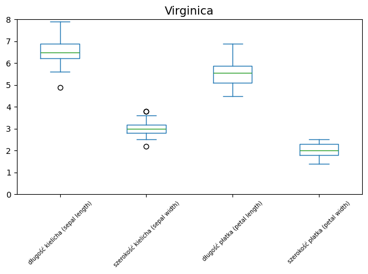

## **WNIOSKI KOŃCOWE**:

#### Dane zawarte w bazie danych iris.csv umożliwiają szczegółową analizę trzech gatunków irysów – Iris setosa, Iris versicolor oraz Iris virginica – w kontekście rozmiarów ich kielichów oraz płatków. Analiza tych danych pozwala na szereg interesujących obserwacji.

#### Pierwszym istotnym wnioskiem jest to, że Iris versicolor wyróżnia się najbardziej regularnym kształtem kwiatu spośród wszystkich analizowanych gatunków. Charakteryzuje się on stabilnymi wymiarami, co sugeruje większą jednorodność w budowie tego gatunku. Z kolei Iris setosa posiada najbardziej powtarzalny rozmiar płatka, co oznacza, że wartości długości płatków w tym gatunku wykazują najmniejsze rozbieżności. Oznacza to, że w przypadku Iris setosa obserwujemy wyraźną koncentrację w rozmiarach płatków wokół jednej wartości, co może świadczyć o wyższej stabilności cechy w tym gatunku.

#### Analizując dane, zauważamy także, że rozmiary kielichów i płatków w przypadku Iris virginica są nieco bardziej zróżnicowane, co może sugerować większą zmienność w tym gatunku. Równocześnie, wyniki wskazują, że długość kielicha w większym stopniu koreluje z szerokością kielicha w przypadku Iris setosa, w porównaniu do Iris versicolor i Iris virginica. Dodatkowo, długość płatka w największym stopniu koreluje z szerokością płatka w Iris versicolor, co może sugerować bardziej spójny i proporcjonalny rozwój tych elementów w tym gatunku.

#### Podsumowując, analiza danych pokazuje nie tylko różnice w rozmiarach kwiatów, ale także różnorodność w strukturze i regularności poszczególnych gatunków irysów. Iris versicolor prezentuje wyjątkową regularność kształtu, podczas gdy Iris setosa wyróżnia się stabilnością rozmiaru płatków, co może być interesującym punktem wyjścia do dalszych badań nad genetyką i ekologią tych roślin.

[output not shown]

[output not shown]